# Trabajo Final Estadística Multivariada

Mario Becerra 124362

4/05/2015

# Introducción

La Encuesta Nacional de Ingresos y Gastos de los Hogares 2012 (ENIGH-2012) es hecha cada dos años por el INEGI. La ENIGH-2012 se levantó en el periodo que abarca del 27 de agosto al 21 de noviembre y tuvo como objetivo proporcionar información sobre la distribución, monto y estructura del ingreso y gasto de los hogares; adicionalmente, ofrece información sobre las características sociodemográficas y ocupacionales de los integrantes del hogar, así como la infraestructura de la vivienda y el equipamiento del hogar. Los resultados de este levantamiento se presentan a nivel nacional como para los ámbitos rural y urbano.

# Análisis Exploratorio de Datos

Los resultados que presenta el INEGI se muestran en doce tablas, sin embargo para este documento, se tomaron en cuenta únicamente las variables reportadas por las tablas **Concentrado, Población y Hogares** y se realizará un reporte de los principales hallazgos. La descripción de las variables se puede ver en la tabla 1.

A continuación se puede ver en un mapa los lugares de la República Mexicana en los que se tienen datos muestrales, clasificados de acuerdo al ámbito (rural o urbano), donde el tamaño del punto depende del número de encuestados en cada localidad.

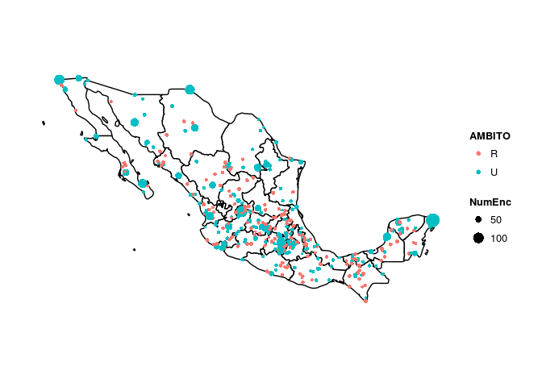

En la siguiente grafica se ve que la distribución de número de viviendas encuestadas por estado está bastante bien equilibrada.

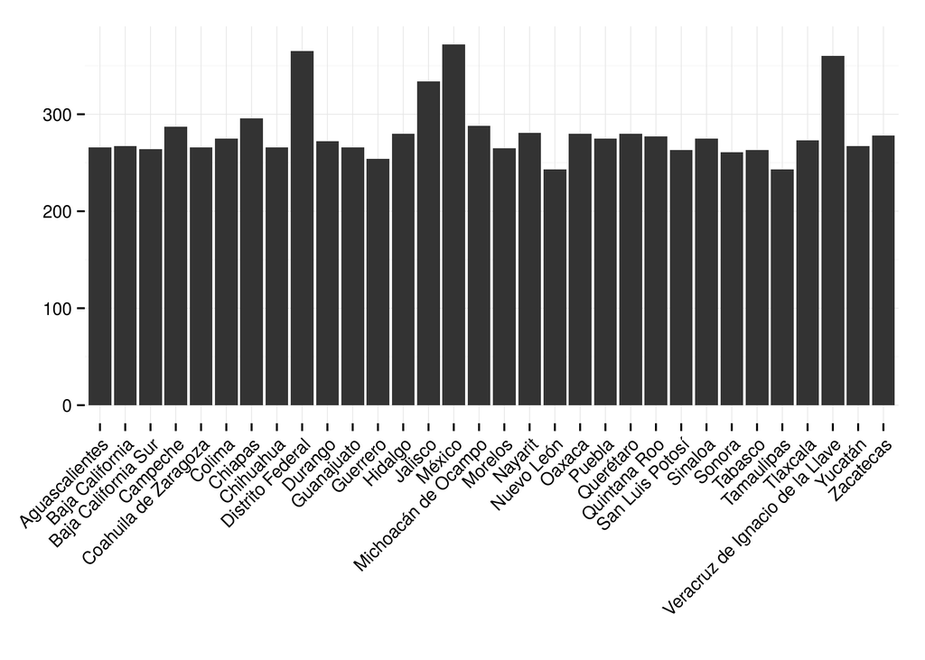

En la siguiente figura se observa la proporción del gasto total que se invirtió en distintos ámbitos por los hogares mexicanos.

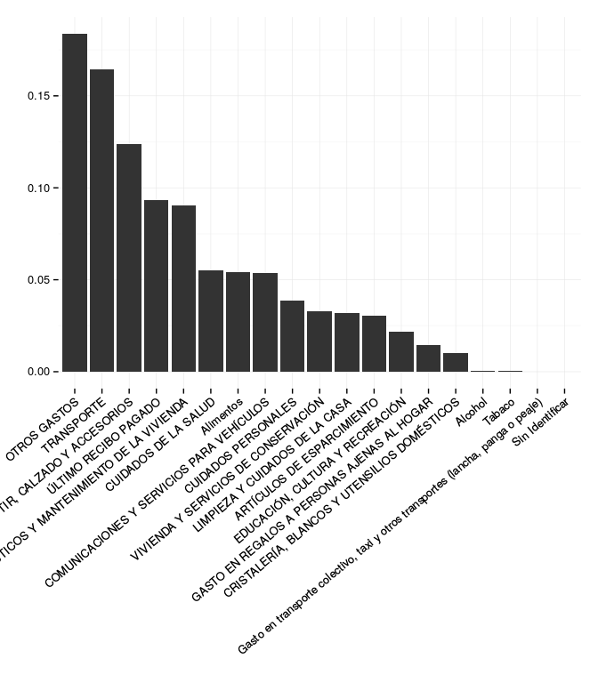

En la siguiente figura se observan gráficas de caja y brazos del ingreso corriente y gasto monetario por estado. Como se puede ver, y como es por muchos sabido, la distribución del ingreso no es nada equitativa entre la población mexicana.

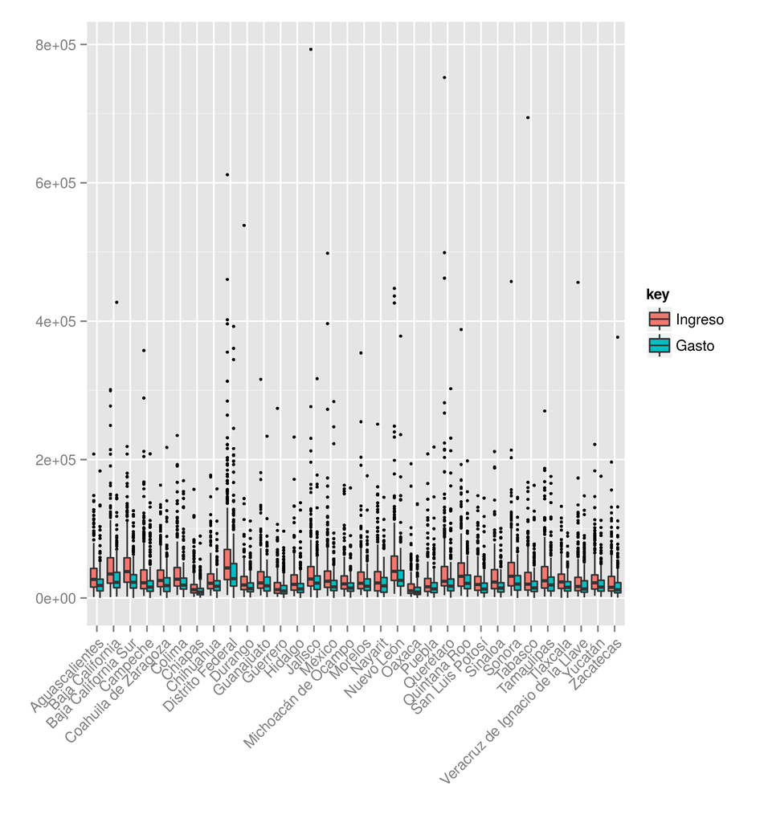

Una medida para medir la distribución del ingreso muy utilizada en la economía y en otras ciencias sociales es el índice de Gini. En forma resumida, el índice de Gini es 0 si toda la población de un área tiene el mismo ingreso; y es 1 si todo el ingreso está concentrado en una sola persona. El índice de Gini estimado a partir de la ENIGH para toda la república es de $0.4641$. A continuación se presenta un mapa donde se puede ver el índice de Gini estimado en cada estado a partir de los datos de la ENIGH.

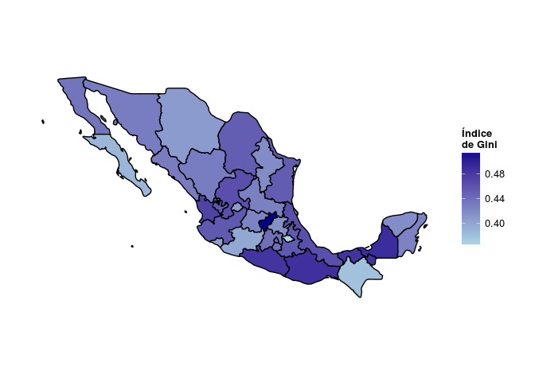

# Modelos Gráficos

Los modelos gráficos son modelos probabilísticos en los que las independencias condicionales entre variables aleatorias se pueden representar a través de una gráfica. Nos interesan estas gráficas por lo que pueden representar acerca de la estructura de la distribución conjunta de las variables. Como la distribución conjunta es el modelo completo del fenómeno, entonces a partir de ella se pueden contestar cualquier pregunta de inferencia, asociación, independencia, etc.

En el caso de este trabajo, en la tabla **Concentrado, Población y Hogares** se tienen 136 variables; sin embargo, muchas de ellas pueden ser redundantes, debido a esto, se utiliza conocimiento externo para seleccionar las variables que son de nuestro interés.

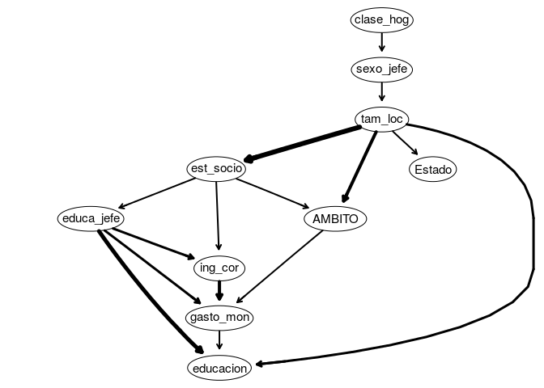

Se pueden encontrar más independencias condicionales en esta gráfica, pero no se analizarán pues a continuación se presenta un enfoque más robusto de las variables.

## Redes promedio

Para desechar relaciones espurias y tener redes más robustas, un enfoque muy utilizado es generar muestras bootstrap de los datos y crear una red para cada muestra, para después crear una red promedio. Esto ayuda a que las relaciones que se mantienen sean más fuertes, pues se reduce el impacto de los máximos locales en el proceso de aprender la estructura. La red promedio que se presenta a continuación se creó a partir de 500 simulaciones bootstrap y usa arcos con fuerza mayor a 0.9, esto significa que se usan los arcos que están presentes al menos un 90% de las redes creadas.

Esta red promedio se puede ver a continuación.

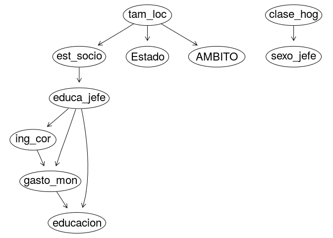

En esta red se puede ver que si se sabe el tamaño de la localidad, entonces el saber el estado de donde viene un encuestado no aporta información sobre las demás variables. El caso análogo al estado es el ámbito de la localidad (rural o urbano). Quizá lo que más llama la atención es que, según esta red, el sexo del jefe del hogar solo tiene relación con la clase de hogar y con ninguna otra variable.

Otra cosa que se puede ver en esta red es que la educación del jefe de familia tiene relación directa con el ingreso corriente (no es tema muy nuevo, ha habido muchos estudios en los que se encuentra esto), en el gasto monetario y en el gasto en educación. Esto tiene sentido, pues se ha dicho que a mayor educación hay más ingreso, y es natural pensar que si hay más ingreso entonces hay más gasto; como se ve en esta gráfica.

Otra cosa que se puede ver en esta gráfica si se presta atención, es que que gasto monetario y estrato socioeconómico están d-separados por la educación del jefe de familia; esto significa que si se sabe la educación del jefe de familia, saber el gasto monetario no dice nada sobre el estrato socioeconómico, y viceversa.

El ingreso corriente y el estrato socioeconómico también están d-separados por la educación del jefe de familia, por lo que pasa lo mismo que con el gasto monetario.

## Conocimiento experto

Otra cosa que también se utiliza en el ámbito de los modelos gráficos probabilísticos es incorporar conocimiento externo al modelo. En este caso, como el principal interés de este trabajo es el ingreso, entonces se pondrá a este como variable respuesta, es decir, no se permitirá que exista ninguna arista que vaya de *ing_cor* a otra variable.

Además de incorporar el conocimiento externo, se ultilizan simulaciones bootstrap nuevamente para hacer más robusto el modelo. Se hacen 500 simulaciones y se filtran las relaciones que aparecen un 90% de las veces.

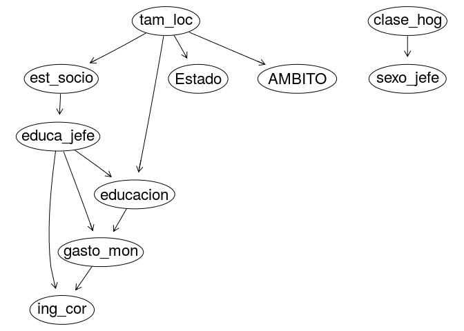

Vemos que en esta red en la cual se le incorpora conocimiento externo guarda muchas de las relaciones que la última que se creó. Las independencias condicionales del tamaño de la localidad, el ámbito y el estado se mantienen; así como las de clase de hogar y el sexo del jefe de familia.

# Modelos de mezclas Gaussianas

```
## ----------------------------------------------------
## Gaussian finite mixture model fitted by EM algorithm
## ----------------------------------------------------
##
## Mclust VEV (ellipsoidal, equal shape) model with 3 components:
##
##  log.likelihood    n  df     BIC     ICL
##         -339056 8975 179 -679740 -680057
##
## Clustering table:
##    1    2    3
## 2583 1752 4640
##
## Mixing probabilities:
##      1      2      3
## 0.2864 0.1994 0.5143
##
## Means:
##                 [,1]      [,2]      [,3]
## tam_loc        1.782     3.386     2.584
## est_socio      2.292     1.693     1.929
## clase_hog      2.332     2.275     2.007
## sexo_jefe      1.256     1.187     1.270
## educa_jefe     5.066     4.332     3.681
## ing_cor    42227.090 45274.440 24240.267
## gasto_mon  29625.718 31997.685 15195.439
## educacion   4828.615  2421.477     0.000
## Estado        16.365    17.245    16.201
## AMBITO         2.000     1.199     1.615
##
## Variances:
## [,,1]
##               tam_loc  est_socio  clase_hog  sexo_jefe educa_jefe
## tam_loc     1.324e+00 -4.027e-01    0.03149 -9.123e-03    -0.6087
## est_socio  -4.027e-01  8.647e-01    0.01896  7.551e-02     0.7249
## clase_hog   3.149e-02  1.896e-02    0.69295  1.350e-01    -0.3376
## sexo_jefe  -9.123e-03  7.551e-02    0.13495  2.742e-01    -0.1304
## educa_jefe -6.087e-01  7.249e-01   -0.33760 -1.304e-01     6.9883
## ing_cor    -6.621e+03  1.126e+04 1749.02946 -4.607e+02 40023.3436
## gasto_mon  -4.206e+03  6.938e+03  724.86894 -4.516e+02 25295.7248
```

[output cut: 45 more lines]

```
## gasto_mon  -5.158e+03  3.721e+03  1.551e+03 -3.847e+02  1.183e+04
## educacion  -3.549e-19 -4.301e-17  4.622e-17  2.978e-16  1.221e-17
## Estado      3.524e+04 -2.734e+04  4.629e+03 -1.605e+03 -3.163e+04
## AMBITO     -1.058e+02  8.196e+01 -1.387e+01  4.808e+00  9.523e+01
##               ing_cor  gasto_mon  educacion     Estado     AMBITO
## tam_loc    -9.373e+03 -5.158e+03 -3.549e-19  3.524e+04 -1.058e+02
## est_socio   6.620e+03  3.721e+03 -4.301e-17 -2.734e+04  8.196e+01
## clase_hog   2.565e+03  1.551e+03  4.622e-17  4.629e+03 -1.387e+01
## sexo_jefe  -3.612e+02 -3.847e+02  2.978e-16 -1.605e+03  4.808e+00
## educa_jefe  1.769e+04  1.183e+04  1.221e-17 -3.163e+04  9.523e+01
## ing_cor     3.321e+08  1.594e+08 -3.368e-23 -1.849e+04  3.041e+03
## gasto_mon   1.594e+08  1.430e+08  4.801e-22 -9.426e+03  1.781e+03
## educacion  -3.368e-23  4.801e-22  3.255e-05 -1.572e-19 -4.550e-18
## Estado     -1.849e+04 -9.426e+03 -1.572e-19  2.585e+06 -7.726e+03
## AMBITO      3.041e+03  1.781e+03 -4.550e-18 -7.726e+03  2.330e+01
```

# Anexo

Tabla 1:

Descripción de las variables

| Variable | Descripción |
| --- | --- |
| folioviv | Identificador de la vivienda |
| foliohog | Identificador del hogar |
| ubica_geo | Ubicación geográfica |
| ageb | AGEB |
| tam_loc | Tamaño de localidad |
| est_socio | Estrato socioeconómico |
| est_dis | Estrato de diseño muestral |
| upm | Unidad primaria de muestreo |
| factor_hog | Factor de expansión del hogar |
| clase_hog | Clase de hogar |
| sexo_jefe | Sexo del jefe del hogar |
| edad_jefe | Edad del jefe del hogar |
| educa_jefe | Educación formal del jefe del hogar |
| tot_integ | Número de integrantes del hogar |
| hombres | Integrantes del hogar hombres |
| mujeres | Integrantes del hogar mujeres |
| mayores | Integrantes mayores |
| menores | Integrantes menores |
| p12_64 | Integrantes de 12 a 64 años |
| p65mas | Integrantes de 65 años y mas |
| ocupados | Número de ocupados |
| percep_ing | Perceptores de ingreso |
| perc_ocupa | Perceptores de ingreso ocupados |
| ing_cor | Ingreso corriente |
| ingtrab | Ingreso por trabajo |
| trabajo | Ingreso por trabajo subordinado |
| sueldos | Sueldos |
| horas_extr | Horas extras |
| comisiones | Comisiones y propinas |
| aguinaldo | Aguinaldo |

[output cut: 97 more lines]